# Overview of the Quantitative Histories Workshop

Nathan Alexander, Ph.D.

Howard University

Assistant Professor

Department of Curriculum and Instruction | School of Education

MS Program | Center for Applied Data Science and Analytics

nathan.alexander@Howard.edu

# Quantitative Histories Workshop

`Curriculum & software development collective`

and

research lab

# Research Problem

Increasingly complex problems require complex tools.

Computational tools support interdisciplinary thinking.

# Research Problem

Increasingly complex problems require complex tools.

Computational tools support interdisciplinary thinking.

# Research Problem

Increasingly complex problems require complex tools.

Sub-disciplinary tools require interdisciplinary thinking.

How can information theory inform interdisciplinary curriculum and software development?

# Information theory

Information theory is a branch of applied mathematics and computer science that deals with the quantification, storage, transmission, and manipulation of information. We take an abstract approach to our study of information.

- Information theory seeks to measure the amount of information contained in a *message* or signal and how efficiently it can be transmitted or stored.
- In this way, our projects define *information* using a curricular perspective.

# Quantitative history

[figure not shown]

*Historie Quantitative* by Pierre Chaunu

# Mathematical sociology

[figure not shown]

*Journal of Mathematical Sociology*

# Curriculum and software development

Design, development, implementation, and evaluation of computational curricular materials

## Research projects

- ECHO: Education, Community, and Health Observations
  - Information and spatial segregation
- Teaching statistical learning and mathematical modeling
- Theory and quantification

## Project group 1: Spatial information and racial isolation

How do patterns of racial segregation inform education, community, and health outcomes?

- Historical legacies of injustice
- Traditional modeling approaches
- Modern computational tools

# Dividing walls

# Geometric approach

We adopt a **topological** model for spatial segregation on a geographical area, $G$ to develop a theory of dividing walls.

Builds on the topological and topographical work of Short (2011).

**Theorem 1**. Given any configuration of blue and green towns, there is a dividing wall that separates blue towns from green towns.

[figure not shown]

Geographic area with neighborhood units

**Theorem 1**. Given any configuration of blue and green towns, there is a dividing wall that separates blue towns from green towns.

[figure not shown]

Geographic area with neighborhood units

**Theorem 1**. Given any configuration of blue and green towns, there is a dividing wall that separates blue towns from green towns.

[figure not shown]

Geographic area with wall dividing neighborhood units

## Is there a dividing wall for an island with coastal towns?

[figure not shown]

Island with coastal towns

## Is there a dividing wall for an island with coastal towns?

[figure not shown]

Minimal configuration

[figure not shown]

Alternating configuration (left) and non-alternating configuration (right).

**Theorem 2**. Alternating configurations of towns do not have a dividing wall, whereas non-alternating configurations of towns do have a dividing wall.

### Algebraic approach

We then develop a algebraic modeling approach using methods from **mathematical sociology**.

Segregation indices

- *Dissimilarity index*: Measures the proportion of one group’s population that would need to move to achieve an even distribution across all areas. It ranges from 0 to 1, with higher values indicating greater segregation.
- *Isolation index*: Measures the extent to which members of a particular group are surrounded by others from the same group. It represents the percentage of people from a specific group who would need to change neighborhoods to achieve an even distribution. Higher values indicate higher isolation and segregation.

### Algebraic approach

We then develop a algebraic modeling approach using methods from **mathematical sociology**.

Segregation indices

- *Exposure index*: Measures the extent to which members of one group are exposed to members of another group. It quantifies the likelihood that a randomly selected individual from one group will encounter individuals from another group. Higher values indicate higher exposure and lower segregation.
- *Concentration index*: Measures the extent to which a particular group is concentrated in specific areas or neighborhoods. It reflects the degree of clustering or dispersion of the group’s population across geographic units.
- *Gini index*: Measure of income inequality, but it can also be adapted to measure residential segregation. It provides a summary measure of the overall distribution of different groups across neighborhoods.

## Index of Dissimilarity

$$D = \dfrac{1}{2} \sum_\limits{i=1}^n \bigg| \frac{b_i}{B} - \frac{w_i}{W} \bigg|$$

- $n$ is the number of neighborhoods in a geographic region,
- $b_i$ is the number of Black household units in neighborhood $i$,
- $B$ is the total number of Black household units in the geographic region,
- $w_i$ is the number of non-Black household units in neighborhood $i$,
- $W$ is the total number of non-Black household units in the geographic region,

[figure not shown]

Co-authored student research poster.

## Computational approach

Teaching computational methods and open source tools makes for efficient and accurate learning. In about 20 lines of code, there is an immediate intersection.

```r
black_georgetown_sc_2020 <-
  get_acs(geography = "tract", state = "SC",
          county = "Georgetown",
                        variable = "B02001_003", # Black or African American Alone
                        geometry = TRUE)
```

Estimate of Black or African American alone in Georgetown county, SC.

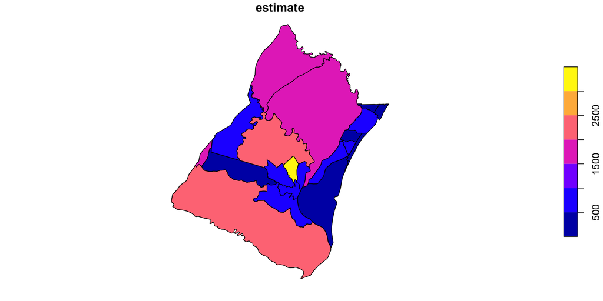

# Historical and broader applications

Social politics of maps.

- Introductory module used in graduate course in statistics.
- `critstats` package developed for students to download and explore culturally relevant data.

### Historical applications

[figure not shown]

Distribution of Negroes in the United States.

### Broader applications

[figure not shown]

True Size of Africa.

## Project group 2: Mining archives and historical text: Analysis of sentiments and textual data

- Inquiry into the speeches of historical figures, such as civil rights activists.
- Exploration of journal articles and citations related to historical of inequity

### Theoretical foundations of sentiment analysis

History, political science, and sociology inform theory development

[figure not shown]

Ida B. Wells-Barnett

[figure not shown]

W. E. B. Du Bois

[figure not shown]

Income and Expenditure of 150 Negroe Families in Atlanta

### Exploration of journal articles and citations related to historical of inequity

Topic modeling research approach in STEM education journals

- Bibliometric analysis: who is citing who? who is discussing what?
- Topic modeling: what are networks discussing?

Topic modeling research approach in STEM education journals

- What are the historical trends and patterns in the research on racism as reflected in journal articles?

[figure not shown]

Topic modeling approach

### Hypothesis 1: Peaks in research occur within some key historical interval $(t_1, t_2)$.

[figure not shown]

Publications and citations related to racism in STEM education

### Hypothesis 2: These intervals are lag models of broader system searches $(t_1, t_2)$.

[figure not shown]

Searches related to racism

# Products

- `critstats` software package. An abstract introduction to critical statistics.
- Playbook for educators to support and improve data science education.

# Broad Implications

- K-12 teaching and learning
  - This also exposes students to a diversity of problems and methods to solve those problems.
- Computationally-focused research and training in higher education
  - Provides an equitable pathway and entry into “high information, high density” conversations.
- Industry and professional organizations